# Summative Assessment

2659993 (Student ID)

03/01/2024

# Gender Influence in the UK Adult Population Mental Health in 2018-2019

## 1. Introduction

The links between mental health and gender have become increasingly evident in recent years, although most research in the field still minimises or ignores gender differences in mental health (Patalay and Demkowicz, 2023). Spencer and Broome (2023) call for an urgent need to better understand young women’s mental health, as an NHS digital survey shows rates of diagnosed mental illness rise as children approach adulthood: 15% of 7-10 years-old against 22% of 17-24 years-old have a diagnosable disorder (Newlove-Delgado et al., 2022). There is also evidence that the decline in mental health during the Covid-19 outbreak was twice as large for women as for men in the UK (Etheridge and Spantig, 2022).

Hence, this essay aims to address the following research question: “Is there a gender gap in the UK adult population mental health in 2018-2019?”. To answer this, we will utilise data from the Understanding Society Wave 10 dataset (University of Essex, 2023b). Understanding Society is the UK Household Longitudinal Study, a survey of the members of approximately 40,000 households (Wave 1). It collects data on subjects such as health, work, education, income, family and social life, with both objective and subjective indicators. Waves indicate the answers of sample members in a particular year (University of Essex, 2023a).

Our outcome variable is the 12-Item Short Form Survey (SF-12) Mental Component Summary (MCS). This is a derived variable that converts valid answers from questions on the “Self-Completion SF12 Module” of the individuals’ survey questionnaire into a single mental functioning score. The score is a continuous scale ranging from 0 (low functioning) to 100 (high functioning) (University of Essex, 2023a).

## 2. Data

### 2.1 Variables

The following variables displayed in Table 1 were selected from the individual response questionnaire to be used in the analysis:

Table 1: Variable names and definitions

| Variable | Description |
| --- | --- |
| SF-12 Mental Component Summary (MCS) | Single mental functioning score, ranging from 0 to 100 |
| Sex | Sex (male/female) |
| Age | Age, in completed years, at the time of interview |
| Residential area | Binary indicator classifying the address as falling into an urban or rural area |
| Marital status | Legal marital status |
| Education | Highest educational qualification |
| Job status | Current employment situation |
| Individual monthly income | Total estimated net monthly income in pounds (£) |
| Ethnic group | Ethnic group |
| Loneliness | How often feels lonely |
| Parental responsibility | Whether responsible for child under 16 |
| Hours on housework per week | Hours spent on housework per week (e.g. cooking, cleaning, doing the laundry) |

It is important to note that some variables the literature points as having an influence on mental health wellbeing are not included in the selection. Consumption of alcohol is associated with impacts on mental health (Newton-Howes and Boden, 2016) but the variable in Understanding Society Wave 10 *dklm* (“How many times in the last four weeks have you had an alcoholic drink?”) has over 90% of “inapplicable” answers. Similar situation is observed with *ypnpal* (number of close friends - question was only asked to respondents aged 16-21) and *aidhrs* (number of hours spent per week on caring), both relevant aspects to mental health wellbeing (Etheridge and Spantig, 2022; Madia et al., 2023). Potential implications to the final model are discussed later.

### 2.2 Cleaning the data

```r
dim(project_dataset_fv)
```

```
## [1] 34318    13
```

The Understanding Society Wave 10 dataset has responses from 34,318 individuals. To proceed with the analysis, some filters are applied to make sure only relevant observations are included. The criteria set for filtering are as follows, and each one was performed individually to check how many observations are dropped at each stage:

- Include only people aged 16 or above, since the focus is on the adult population
  - Only 3 observations are dropped.
- For individual monthly income, exclude negative values (monthly income below 0)
  - A drop of 15 observations.
- For individual monthly income, exclude very high values (monthly income > 25000)
  - Five observations are removed.
- Exclude missing values within independent variables
  - Age: no drops.
  - Sex: two observations removed.
  - Residential area: 24 observations are dropped.
  - Individual monthly income: no drops.
  - Marital status: 1,000 observations removed.
  - Job status: 30 observations are excluded.
  - Ethnic group: 11 observations dropped.
  - Loneliness: A drop of 1,385 observations.
  - Parental responsibility: no drops.
  - Hours on housework per week: 1,008 observations are removed.
  - Education: 4,148 observations are dropped (13%). This might be a considered reduction. Looking in the data documentation, we can see this variable has originally 13.57% of its observations as “inapplicable”. It is not possible to know exactly the reason of missingness, but we can speculate those respondents might not have had access to formal education. According to the Office for National Statistics, 18.2% of the adult population in England and Wales reported having no qualifications at all in the 2021 Census (Office for National Statistics, 2021). Nevertheless, the survey has the option of answering “None of the above”, which probably represents people with no qualifications (18.85% of observations are for that answer). Hence we are not sure what the missing answers might represent, but decide to drop them anyway.
- Exclude missing values within the dependent variable
  - 391 observations are excluded.

After applying these filters, the final sample size is dropped to 26,296 observations (a drop of roughly 23.4% from the original data sample).

```r
dim(project_dataset_fv_clean)
```

```
## [1] 26296    13
```

### 2.3 Summary statistics

Table 2 shows summary statistics for the variables, grouped by sex (main independent variable of the analysis). The dependent variable (SF-12 Mental Component Summary), age, individual monthly income and hours on housework per week are continuous (numerical) variables, hence the mean, standard deviation and range were calculated for them. All other variables are categorical and display the count of observations and their proportion in percentage numbers in relation to the sample.

Additionally, in order to make descriptive analysis and modelling more manageable, we reduced the number of levels in some factor variables by aggregating them. These variables are marital status (9 levels aggregated to 4), education (17 levels to 4), job status (12 levels to 5) and ethnic group (18 levels to 2).

Table 2: Summary statistics for variables used in the analysis

| **Variable** | **Overall**, N = 26,296<sup>1</sup> | **Male**, N = 11,669<sup>1</sup> | **Female**, N = 14,627<sup>1</sup> |
| --- | --- | --- | --- |
| SF-12 Mental Component Summary (MCS) |  |  |  |
| Mean (SD) | 47.77 (10.71) | 49.16 (10.11) | 46.67 (11.05) |
| Range | 0.00 - 75.38 | 0.45 - 73.56 | 0.00 - 75.38 |
| Age |  |  |  |
| Mean (SD) | 48.41 (18.54) | 48.84 (18.60) | 48.06 (18.49) |
| Range | 16.00 - 99.00 | 16.00 - 99.00 | 16.00 - 98.00 |
| Residential area |  |  |  |
| Urban area | 19,967 (76%) | 8,804 (75%) | 11,163 (76%) |
| Rural area | 6,329 (24%) | 2,865 (25%) | 3,464 (24%) |
| Marital status |  |  |  |
| Single | 8,269 (31%) | 3,717 (32%) | 4,552 (31%) |
| Married | 13,850 (53%) | 6,624 (57%) | 7,226 (49%) |
| Divorced | 2,754 (10%) | 966 (8.3%) | 1,788 (12%) |
| Widowed | 1,423 (5.4%) | 362 (3.1%) | 1,061 (7.3%) |
| Education |  |  |  |
| Higher education degree or similar | 10,592 (40%) | 4,443 (38%) | 6,149 (42%) |
| College (A levels or similar) | 3,079 (12%) | 1,405 (12%) | 1,674 (11%) |
| School (GSCE or similar) | 7,180 (27%) | 3,297 (28%) | 3,883 (27%) |
| None | 5,445 (21%) | 2,524 (22%) | 2,921 (20%) |
| Job status |  |  |  |
| Employed (self employed or paid employment [FT/PT]) | 15,253 (58%) | 7,113 (61%) | 8,140 (56%) |
| Unemployed | 968 (3.7%) | 490 (4.2%) | 478 (3.3%) |
| Retired | 6,127 (23%) | 2,786 (24%) | 3,341 (23%) |
| Maternity leave; family care or home | 1,106 (4.2%) | 71 (0.6%) | 1,035 (7.1%) |
| Other | 2,842 (11%) | 1,209 (10%) | 1,633 (11%) |
| Individual monthly income (£) |  |  |  |
| Mean (SD) | 1,622.35 (1,429.37) | 1,930.16 (1,663.61) | 1,376.78 (1,152.97) |
| Range | 0.00 - 24,702.35 | 0.00 - 24,702.35 | 0.00 - 24,000.00 |
| Ethnic group |  |  |  |
| British (English, Scottish, Welsh), Northern Irish, Irish or other white background | 21,917 (83%) | 9,822 (84%) | 12,095 (83%) |
| Other ethnic group | 4,379 (17%) | 1,847 (16%) | 2,532 (17%) |
| Loneliness |  |  |  |
| Hardly ever or never | 16,108 (61%) | 7,813 (67%) | 8,295 (57%) |
| Some of the time | 8,118 (31%) | 3,111 (27%) | 5,007 (34%) |
| Often | 2,070 (7.9%) | 745 (6.4%) | 1,325 (9.1%) |
| Parental responsibility |  |  |  |
| Yes | 3,877 (15%) | 82 (0.7%) | 3,795 (26%) |
| No | 22,419 (85%) | 11,587 (99%) | 10,832 (74%) |
| Hours on housework per week |  |  |  |
| Mean (SD) | 9.55 (8.94) | 6.60 (7.01) | 11.90 (9.59) |
| Range | 0.00 - 168.00 | 0.00 - 168.00 | 0.00 - 140.00 |

<sup>1</sup> Mean (SD) or Frequency (%)

It is possible to see that the mean score of the SF-12 Mental Component Summary scale is 46.67 for women and 49.16 for men. This is a considerable difference. To test if this difference is applicable to the general population, a t-test is performed between the dependent variable and the key independent variable (which is a “dummy” variable - categorical with two levels, reason why a t-test is performed instead of Anova or Correlation tests).

## 3. Inferential Statistics

```r
t.test(sf12mcs ~ sex, data = project_dataset_fv_clean)
```

```
##
##  Welch Two Sample t-test
##
## data:  sf12mcs by sex
## t = 19.023, df = 25808, p-value < 2.2e-16
## alternative hypothesis: true difference in means between group Male and group Female is not equal to 0
## 95 percent confidence interval:
##  2.231401 2.744054
## sample estimates:
##   mean in group Male mean in group Female
##             49.15713             46.66941
```

The level of significance (p-value) adopted is the conventional value of 0.05. By running the t-test, we tested the null hypothesis that there is no statistical difference between the average mean Mental Component Summary score for men and women in the population. The p-value obtained is smaller than 0.05, thus we reject the null hypothesis.

## 4. Visualising the output variable

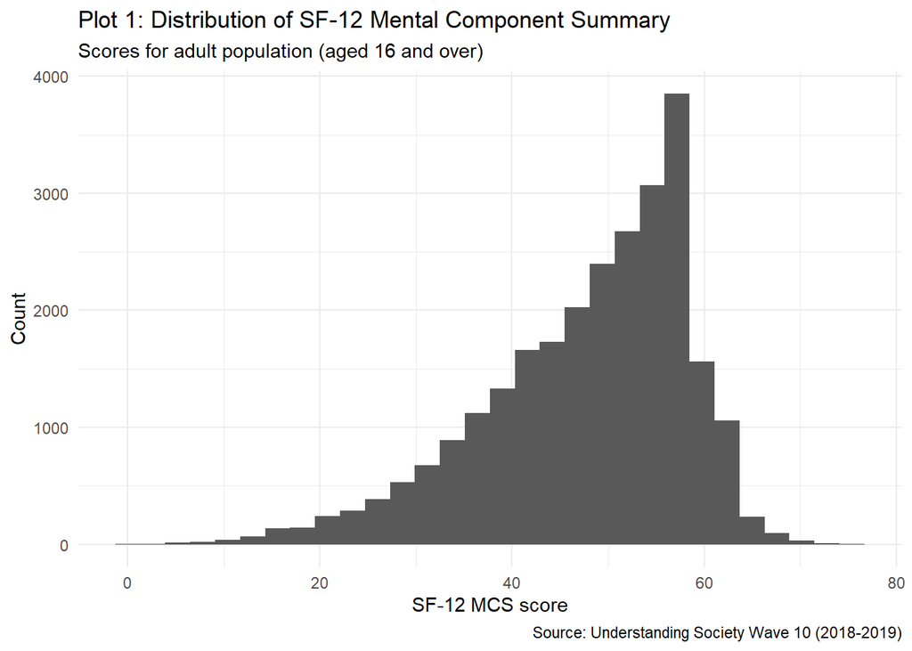

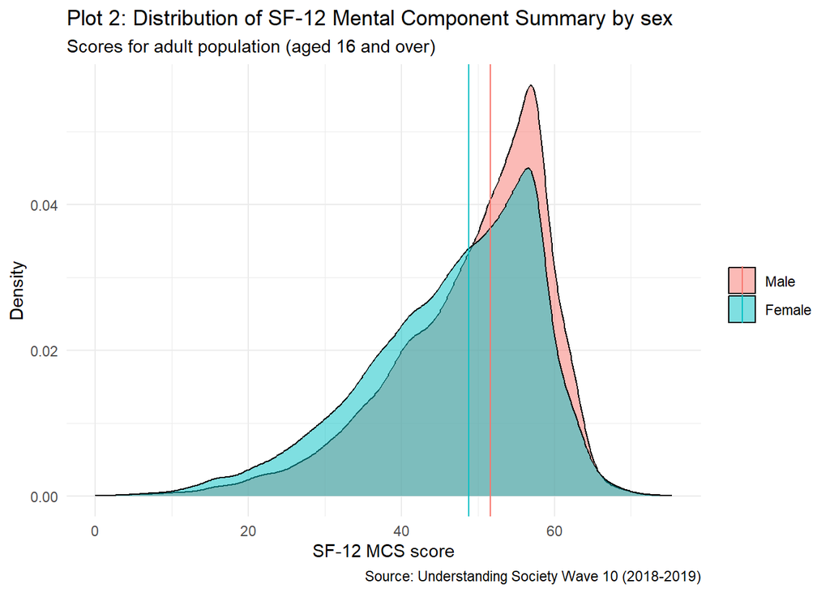

The vertical lines represent the median SF-12 MCS scores both for men and women. The median for men is higher than for women.

## 5. Analysis - linear regression and model building

After demonstrating there is a statistically significant difference in the average MCS score of males and females in the t-test, the difference is tested by controlling for other characteristics in the UK adult population. These characteristics (or variables) were selected based on the literature review that indicated the most commonly influencing factors on mental health and gender differences. To do this, Ordinary Least Squares (OLS) regression models are calculated. OLS estimates the line to best describe the linear relationship between a predictor and an outcome variable (in bivariate regression models) or a multidimensional plane in multiple regression models (Fogarty, 2019).

Therefore, five regression models are presented in Table 3:

- Model 1 (M1, the bivariate model): the baseline model with the dependent variable (SF-12 MCS) and the key independent variable of the analysis (sex).
- Model 2 (M2, demographic factors model): M1 added with the age, marital status, highest level of education and ethnic group variables.
- Model 3 (M3, economic factors model): M2 with addition of job status and individual net monthly income variables.
- Model 4 (M4, residential factors model): M3 added with residential area variable.
- Model 5 (M5, social and care factors model): M4 with addition of loneliness, parental responsibility and hours per week on housework variables.

Table 3: Regression results for SF-12 MCS (dependent variable)

|  | M1 | M2 | M3 | M4 | M5 |
| --- | --- | --- | --- | --- | --- |
| Intercept | 49.16*** | 42.14*** | 44.39*** | 44.18*** | 48.59*** |
|  | (0.10) | (0.23) | (0.28) | (0.28) | (0.30) |
| Female | -2.49*** | -2.26*** | -2.10*** | -2.10*** | -1.37*** |
|  | (0.13) | (0.13) | (0.13) | (0.13) | (0.13) |
| Age (Years) |  | 0.13*** | 0.08*** | 0.08*** | 0.06*** |
|  |  | (0.00) | (0.01) | (0.01) | (0.01) |
| Marital status (Ref: Single) |  |  |  |  |  |
| Married |  | 1.74*** | 1.28*** | 1.24*** | -0.31 |
|  |  | (0.17) | (0.18) | (0.18) | (0.16) |
| Divorced |  | -0.62* | -0.79** | -0.80** | -0.17 |
|  |  | (0.25) | (0.25) | (0.25) | (0.22) |
| Widowed |  | 0.23 | -0.17 | -0.16 | 1.41*** |
|  |  | (0.35) | (0.35) | (0.35) | (0.31) |
| Education (Ref: Higher education degree or similar) |  |  |  |  |  |
| College (A levels or similar) |  | -0.10 | 0.39 | 0.37 | 0.41* |
|  |  | (0.21) | (0.22) | (0.22) | (0.19) |
| School (GSCE or similar) |  | -0.19 | 0.45** | 0.45** | 0.40** |
|  |  | (0.16) | (0.16) | (0.16) | (0.14) |
| None |  | -1.05*** | -0.35 | -0.34 | -0.15 |
|  |  | (0.18) | (0.18) | (0.18) | (0.16) |
| Ethnic group (Ref: British (English, Scottish, Welsh), Northern Irish, Irish or other white background) |  |  |  |  |  |
| Other ethnic group |  | -0.08 | 0.40* | 0.64*** | 0.77*** |
|  |  | (0.17) | (0.17) | (0.18) | (0.16) |
| Job status (Ref: Employed (self employed or paid employment [FT/PT]) |  |  |  |  |  |
| Unemployed |  |  | -5.35*** | -5.33*** | -3.31*** |
|  |  |  | (0.35) | (0.35) | (0.31) |
| Retired |  |  | 1.43*** | 1.40*** | 0.96*** |
|  |  |  | (0.22) | (0.22) | (0.19) |
| Maternity leave; family care or home |  |  | -1.78*** | -1.77*** | -0.76* |
|  |  |  | (0.33) | (0.33) | (0.30) |
| Other |  |  | -3.97*** | -3.97*** | -2.52*** |
|  |  |  | (0.23) | (0.23) | (0.21) |
| Individual monthly income (£) |  |  | 0.00** | 0.00** | 0.00 |
|  |  |  | (0.00) | (0.00) | (0.00) |
| Residential area (Ref: Urban area) |  |  |  |  |  |
| Rural area |  |  |  | 1.00*** | 0.83*** |
|  |  |  |  | (0.15) | (0.13) |
| Loneliness (Ref: Hardly ever or never) |  |  |  |  |  |
| Some of the time |  |  |  |  | -7.67*** |
|  |  |  |  |  | (0.13) |
| Often |  |  |  |  | -16.22*** |
|  |  |  |  |  | (0.22) |
| Parental responsibility (Ref: Yes) |  |  |  |  |  |
| No |  |  |  |  | 0.36 |
|  |  |  |  |  | (0.19) |
| Hours on housework per week |  |  |  |  | 0.01 |
|  |  |  |  |  | (0.01) |
| R<sup>2</sup> | 0.01 | 0.08 | 0.10 | 0.10 | 0.30 |
| Adj. R<sup>2</sup> | 0.01 | 0.08 | 0.10 | 0.10 | 0.30 |
| Num. obs. | 26296 | 26296 | 26296 | 26296 | 26296 |

***p < 0.001; **p < 0.01; *p < 0.05

Model 1 presents the relationship between the key independent and dependent variables. As demonstrated previously with the inferential test, men tend to have higher average SF-12 MCS scores than women. In this bivariate model, the average difference is of 2.49 points. Adjusted R-squared value of 0.013 indicates this model explains 1.3% of the variance in the SF-12 MCS variable values.

In Model 2 the relationship between the main pair of variables is controlled by adding demographic variables such as age, marital status, highest level of education and ethnic group. In the literature age has a positive correlation with mental health wellbeing (i.e. the gender gap in mental health decreases as people get older) (Kiely et al., 2019). This is also observed in this model as for one year increase in age, MCS scores are expected to increase 0.13 points on average. Being married has been associated with better mental health (Strohschein et al., 2005) and decreased odds of using mental health services (Dolja‑Gore et al., 2018) in Canada and Australia, respectively. This model reflects something similar for the UK population since married status is associated with higher MCS score (1.74 points) and divorced people have scored lower in the scale when compared to the reference category (single). Widowed status is not statistically significant.

Higher levels of education were significantly linked to having a protective effect against anxiety and depression (Bjelland et al., 2008). In Model 2, people with no educational qualifications scored on average 1.05 points less in the MCS scale when compared with people with degrees (reference category). College or school levels were not statistically significant. When it comes to race and ethnicity, black and minority ethnic communities appear to be at greater risk of developing mental health illnesses in the UK (Bamford et al., 2021). Nevertheless, in this model there was not a statistically significant difference between MCS scores of white/British communities (reference) when compared with other minorities. Overall, controlling for demographic variables in Model 2 resulted in a decrease in the mental health gender gap, which is expected due to the multifactorial nature of mental health wellbeing.

In Model 3 economic factors were introduced. Job insecurity has strong evidence from the literature to be associated with mental distress (Chum et al., 2022) whilst income deprivation is a key driver of mental health inequalities, with women’s mental health being potentially more sensitive to poverty (Thomson et al., 2023). In the model, Unemployed, maternity leave / family care or home and other employment situations appear to have a negative impact on mental health functioning when compared to self and paid employment (ref.). Conversely being retired seems to be associated with higher MCS scores. As for individual monthly income, despite being statistically significant, its positive association with the MCS score is very marginal: an increase of £1000 in monthly income represents an average increase of 0.14 points on the mental wellbeing scale.

Interesting to note that the School (GSCE or similar) category on the highest educational level variable is now statistically significant with higher average score than the higher education degree level. Alternatively, the category indicating no educational qualifications is no longer significant. Furthermore, the other ethnic group category has become statistically significant in Model 3 with higher average score than the white/British ethnicity level. These changes between Models 2 and 3 are rather odd as they contradict what the wider literature indicates. Despite that, adjusted R-squared measure for Model 3 indicates it explains approximately 10% of the variation in the SF-12 MCS scores.

Model 4 accounts for residential area characteristics. In the UK, people living in urban areas are more likely to suffer poor physical and mental health than rural populations (Harriss and Hawton, 2011). This reflects in the model as people residing in rural regions present on average one point (1.0) higher scores in the MCS scale than those living in urban areas (ref.). Adjusted R-Squared and the gender gap in the MCS scale remain roughly the same as Model 3 though.

In Model 5, the variables that account for frequency of feeling lonely, parental responsibility and hours in housework per week are added. Loneliness is correlated with worse mental and physical functioning (Lee et al., 2019). People that often feel lonely are likely to have lower MCS scores by roughly 16 points on average when compared to those who hardly ever or never feel solitary (ref). It is also reported that the disproportional burden of unpaid child and house care on women has a negative correlation on their mental health. However, both variables for parental responsibility and hours on housework appear to be not statistically significant in Model 5. This most comprehensive model explains 30% of the variation in the MCS scale, and the gender gap in mental health is estimated at 1.37 points.

Important to note in Model 5 that the married and divorced status are no longer significant as they were in previous models, whereas widowed is now statistically significant. Something similar seems to happen in the education variable with the College category. The individual monthly income variable has also become not significant in this last model.

These changes between models may indicate some of the assumptions of the linear model are being violated. Therefore, in the next session the robustness of the model is tested before the final discussion and conclusions.

## 6. OLS Assumptions and Model Diagnostics

There are a number of assumptions linear regression (and specifically OLS) makes about the data, variables and estimates. If assumptions are not satisfied it is not possible to be sure if our predictions are correct (Fogarty, 2019).

Best Linear Unbiased Estimator (BLUE) assumptions are crucial to ensure estimates minimise error variance (best or efficient, i.e. standard errors are not biased upwards or downwards) and reflect on average the true population parameter (i.e. coefficients are not biased). In order for the model to be BLUE, it is important to check if the four assumptions from the Gauss–Markov theorem hold (Fogarty, 2019). These are:

1. Predictor variables are independent of each other (exogenous variables)
2. Correct functional form (a linear relationship between predictors and outcome variable)
3. Errors have constant variance (homoscedasticity)
4. No autocorrelation between errors (independent observations)

Additionally to the BLUE assumptions, there are other three assumptions of the OLS that have implications for regression results (Fogarty, 2019). Although not as crucial as the BLUE ones, here we also test for them:

5. Errors are normally distributed
6. There is no multicollinearity between variables (predictors are not functions of one other)
7. There are no influential data points (influential outliers)

In this report, the author opted to follow the order of the tutorial exercises to test the assumptions.

### 6.1 Influential outliers (Additional assumption #7)

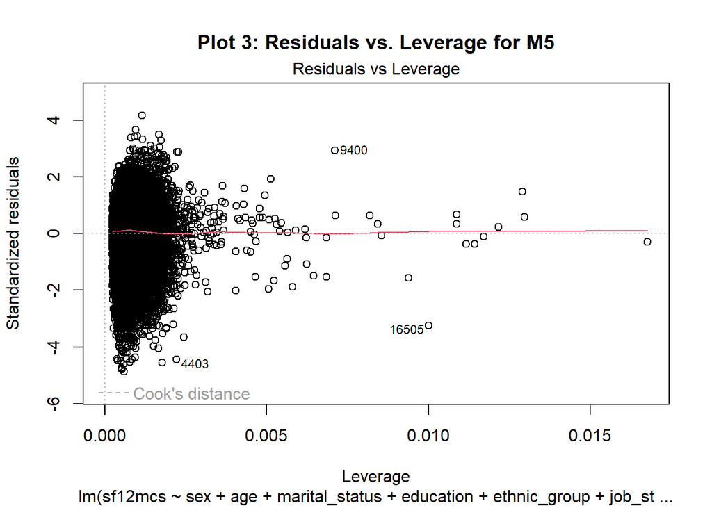

```r
m5 %>%
  plot(which = 5) %>%
  title(main = "Plot 3: Residuals vs. Leverage for M5")
```

Influential data points are tested by looking at Cook’s distance lines, “which measures the effect of each observation on the regression coefficients” (Fogarty, 2019, p.222). If a point is flagged by the Cook’s distance, it is considered an influential outlier. Points with a Cook’s distance greater than 0.5 are considered high, whereas those with distance equal or greater than 1 are extreme influential outliers (Fogarty, 2019).

Here there are no Cook’s distance margins showing in the plot, thus there are no influential outliers in our data.

### 6.2 Correct functional form (BLUE #2)

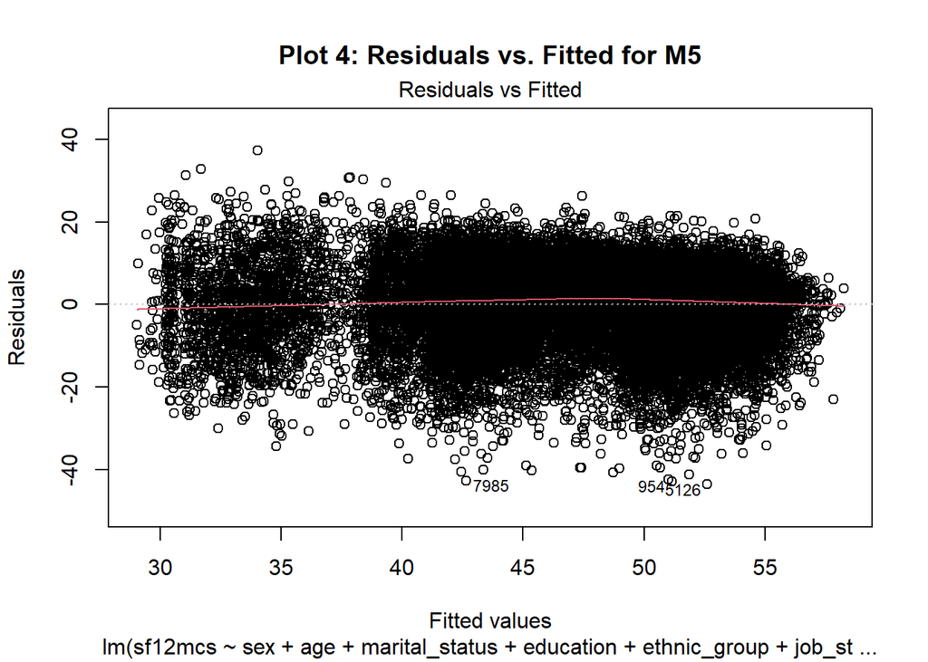

```r
m5 %>%
  plot(which = 1) %>%
  title(main = "Plot 4: Residuals vs. Fitted for M5")
```

In the Residuals vs. Fitted plot, it is possible to see a non-linear pattern in Model 5 (red line is not completely flat, indicating the conditional mean of the error term is not 0). To confirm a potential non-linearity in the model, we also run a Ramsay RESET test where the null hypothesis is that the functional form of the model is correct.

```r
resettest(m5, power = 2:3, type = "fitted")
```

```
##
##  RESET test
##
## data:  m5
## RESET = 35.896, df1 = 2, df2 = 26274, p-value = 2.702e-16
```

The RESET test compares if a new version of our model with predicted values in a non-linear form “explains significantly more variance in the outcome variable than our original model” (Fogarty, 2019, p.219). As the p-value is below 0.05, the null hypothesis is discarded. Therefore, we assume the model has a non-linear functional form.

### 6.3 Errors normally distributed (Additional assumption #5)

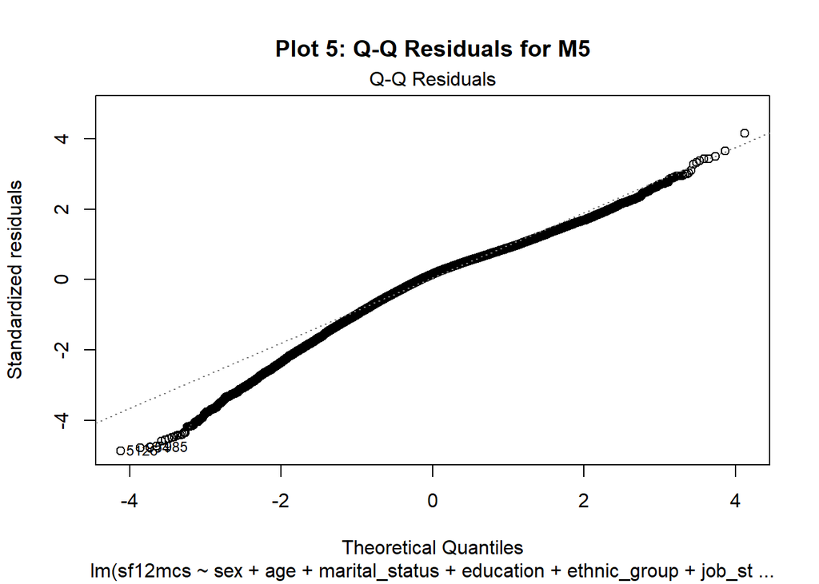

```r
m5 %>%
  plot(which = 2) %>%
  title(main = "Plot 5: Q-Q Residuals for M5")
```

Normally distributed errors are desired because it allows us to generalise the estimates from the sample data to the population. However, violating normality does not mean estimates are wrong, just that we cannot be confident to apply them to statements about the general population (Fogarty, 2019).

### 6.4 Errors have constant variance (BLUE #3)

```r
m5 %>%
  bptest()
```

```
##
##  studentized Breusch-Pagan test
##
## data:  .
## BP = 899.14, df = 19, p-value < 2.2e-16
```

The Residuals vs. Fitted plot may present a pattern of distribution in the residuals, although this is not obvious. To verify if the model presents heteroscedasticity, we run the Breusch–Pagan test. The null hypothesis is that the model has constant error variance (homoscedasticity). The test returns a p-value below the level of significance (p < 0.05), hence we reject the null hypothesis and assume we have an issue of heteroscedasticity.

Heteroscedasticity makes estimates inefficient and standard errors biased downwards. When standard errors are smaller than they should be, we may encounter statistically significant variables which in fact are not (Fogarty, 2019).

### 6.5 No multicollinearity between variables (Additional assumption #6)

```r
m5 %>%
  vif()
```

```
##                    GVIF Df GVIF^(1/(2*Df))
## sex            1.305447  1        1.142562
## age            3.401883  1        1.844420
## marital_status 2.139303  3        1.135129
## education      1.285134  3        1.042697
## ethnic_group   1.110447  1        1.053778
## job_status     3.354139  4        1.163316
## monthly_income 1.291866  1        1.136603
## urban_rural    1.059707  1        1.029421
## lonely         1.111194  2        1.026709
## parental_resp  1.428085  1        1.195025
## hours_hw       1.249682  1        1.117892
```

Multicollinearity is present when two or more independent variables are functions of one other. The variance inflation factor (VIF) test measures how much common variance there is between predictors. VIF value of 1 represent no multicollinearity, and anything below 5 does not cause concern; if it is equal or higher than 10, then it is likely we have issues (Fogarty, 2019).

The results of the VIF test for M5 are low, therefore multicollinearity is not a problem in our model.

### 6.6 Exogenous variables (BLUE #1)

Endogeneity problems occur when there is omitted-variable bias (OVB), which means key predictor variable(s) might have been excluded from the model. Since there is no test that can tell which variables are missing in our model, the best approach to diagnose this issue is reviewing the theory on the subject (Fogarty, 2019).

As mentioned in section 2.1 (Variables), some of the key variables the literature on mental health highlights as relevant have a high level of missingness within the Understanding Society Wave 10 dataset (the case of *dklm* - number of times in the last four weeks respondent has had an alcoholic drink -, *ypnpal* - number of close friends - and *aidhrs* - number of hours spent per week on caring). Furthermore, the variable in our model measuring the frequency of loneliness may have an endogenous relationship with the dependent variable SF-12 MCS. Our hypothesis is that people who often feel lonely have lower scores in the MCS scale (low functioning mental health). Alternatively, those with poorer mental health might be more likely to suffer with illnesses like depression or anxiety, which may lead them to feelings of loneliness more frequently.

Based on those reflections, our model is likely to have endogeneity issues.

### 6.7 No autocorrelation (independent observations) (BLUE #4)

One of the assumptions of the Gauss–Markov theorem is that residuals should be independent (i.e. knowing something about a particular realisation of a residual should not help predict the value of another observation). Problems of autocorrelation are associated with spatial, longitudinal and time series datasets (Fogarty, 2019).

To check for autocorrelation, we should look at the data documentation. Understanding Society is a panel survey of UK households with yearly interviews. In this project we are looking at data from the individual questionnaire instead of the household questionnaire. Despite that, we might have some clustering as all adults in the same household respond the individual questionnaire, hence are more likely to be correlated. This might not be a big issue as there is a large number of households and few people per household. Nevertheless, here we apply cluster robust standard errors to estimate a new model. We assume residuals are correlated within a group (variable *j_hidp*, which specifies the household of respondents) but are independent between groups.

```r
project_dataset_fv_clean %>%
  lm.cluster(data = .,
             sf12mcs ~ sex + age + marital_status + education + ethnic_group +
               job_status + monthly_income + urban_rural + lonely + parental_resp +
               hours_hw,
             cluster = "j_hidp") %>%
  summary()
```

```
## R^2= 0.30299
##
##                                                     Estimate   Std. Error
## (Intercept)                                     4.859102e+01 3.071619e-01
## sexFemale                                      -1.371602e+00 1.264145e-01
## age                                             6.079536e-02 5.747972e-03
## marital_statusMarried                          -3.061750e-01 1.679396e-01
## marital_statusDivorced                         -1.676417e-01 2.395393e-01
## marital_statusWidowed                           1.409851e+00 3.275869e-01
## educationCollege (A levels or similar)          4.090404e-01 1.954845e-01
## educationSchool (GSCE or similar)               4.023713e-01 1.426197e-01
## educationNone                                  -1.538052e-01 1.604385e-01
## ethnic_groupOther ethnic group                  7.697535e-01 1.768614e-01
## job_statusUnemployed                           -3.310795e+00 3.689766e-01
## job_statusRetired                               9.608708e-01 1.858435e-01
## job_statusMaternity leave; family care or home -7.568694e-01 3.072455e-01
## job_statusOther                                -2.515408e+00 2.492546e-01
## monthly_income                                  6.448145e-05 3.936034e-05
## urban_ruralRural area                           8.291398e-01 1.342320e-01
## lonelySome of the time                         -7.673574e+00 1.326254e-01
## lonelyOften                                    -1.621671e+01 2.670278e-01
## parental_respNo                                 3.592691e-01 1.870425e-01
## hours_hw                                        9.152513e-03 7.462999e-03
##                                                    t value     Pr(>|t|)
## (Intercept)                                    158.1935237 0.000000e+00
## sexFemale                                      -10.8500367 1.993453e-27
## age                                             10.5768358 3.816292e-26
## marital_statusMarried                           -1.8231259 6.828432e-02
## marital_statusDivorced                          -0.6998503 4.840208e-01
## marital_statusWidowed                            4.3037466 1.679337e-05
## educationCollege (A levels or similar)           2.0924441 3.639881e-02
## educationSchool (GSCE or similar)                2.8212893 4.783104e-03
## educationNone                                   -0.9586552 3.377325e-01
## ethnic_groupOther ethnic group                   4.3522981 1.347179e-05
## job_statusUnemployed                            -8.9729138 2.887722e-19
## job_statusRetired                                5.1703222 2.336908e-07
## job_statusMaternity leave; family care or home  -2.4634024 1.376253e-02
## job_statusOther                                -10.0917233 6.010496e-24
## monthly_income                                   1.6382344 1.013728e-01
## urban_ruralRural area                            6.1769163 6.536570e-10
## lonelySome of the time                         -57.8590046 0.000000e+00
## lonelyOften                                    -60.7304251 0.000000e+00
## parental_respNo                                  1.9207885 5.475837e-02
## hours_hw                                         1.2263854 2.200537e-01
```

As expected, there is not a considerable difference from our original model.

Furthermore, there is also a possibility of spatial or temporal clustering. It might be that there is some autocorrelation between people in the same city/region/area. Here we have controlled for urban and rural areas. As for clustering over time, we assume this does not occur in our data as we are looking at one specific wave of the Understanding Society survey. Thus our data is cross-sectional (one point in time) and not longitudinal.

All in all, we conclude we do not have autocorrelation issues. Table 4 summarises the results of model diagnostics.

Table 4: Model diagnostics results for M5

| Assumption | Issue? | Plan |
| --- | --- | --- |
| **BLUE Assumptions** |  |  |
| 1. Predictor variables are independent of each other | Yes | Drop *lonely* variable? |
| 2. Correct functional form | Yes | Take logarithm of dependent variable? |
| 3. Errors have constant variance | Yes | Correct with robust standard errors |
| 4. No autocorrelation between errors (independent observations) | No | NA |
| **Additional Assumptions** |  |  |
| 5. Errors are normally distributed | Yes | Take logarithm of dependent variable? |
| 6. There is no multicollinearity between variables | No | NA |
| 7. There are no influential data points | No | NA |

### 6.8 Refining for a final model

To correct for endogeneity, we dropped the *lonely* variable and compared the regression results with the original model. Firstly, the adjusted R-squared decreased from 30% to 10%. Secondly, there are changes in the significance of some variables/categories: for example, parental responsibility and monthly income are now statistically significant, whereas college education and being widowed are not. Finally, running some of the tests for the other assumptions, the Q-Q plot seems more detached from the 45-degree line than when the model includes the variable - indicating we are less confident to generalise the estimates to statements about the population.

Furthermore, some of the literature on the subject has included similar variable to measure level of loneliness in their analysis (Etheridge and Spantig, 2022). Based on these factors, we decided to keep *lonely* in the model, as removing it seemed to cause more omitted-variable bias.

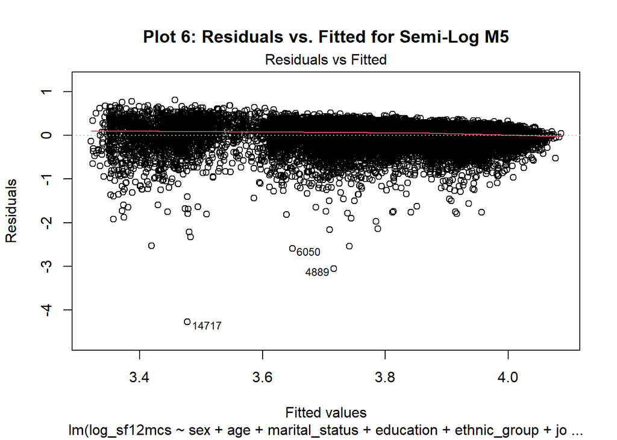

```
##
##  RESET test
##
## data:  m5_log
## RESET = 86.735, df1 = 2, df2 = 26273, p-value < 2.2e-16
```

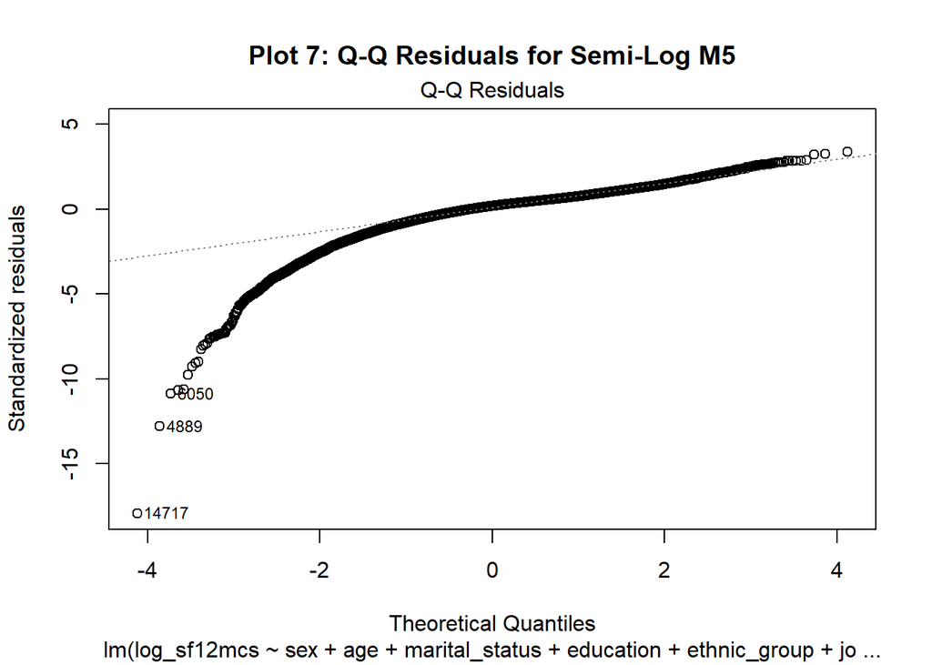

Finally, we correct Model 5 for heteroscedasticity with robust standard errors, presenting it as Model 6 (our selected final specification). No major changes in statistical significance are observed.

Table 5: Final model for SF-12 MCS (dependent variable)

|  | Model 6 |
| --- | --- |
| Intercept | 48.59*** |
|  | (0.30) |
| Female | -1.37*** |
|  | (0.13) |
| Age (Years) | 0.06*** |
|  | (0.01) |
| Marital status (Ref: Single) |  |
| Married | -0.31 |
|  | (0.16) |
| Divorced | -0.17 |
|  | (0.24) |
| Widowed | 1.41*** |
|  | (0.32) |
| Education (Ref: Higher education degree or similar) |  |
| College (A levels or similar) | 0.41* |
|  | (0.19) |
| School (GSCE or similar) | 0.40** |
|  | (0.14) |
| None | -0.15 |
|  | (0.16) |
| Ethnic group (Ref: British (English, Scottish, Welsh), Northern Irish, Irish or other white background) |  |
| Other ethnic group | 0.77*** |
|  | (0.17) |
| Job status (Ref: Employed (self employed or paid employment [FT/PT]) |  |
| Unemployed | -3.31*** |
|  | (0.36) |
| Retired | 0.96*** |
|  | (0.18) |
| Maternity leave; family care or home | -0.76* |
|  | (0.31) |
| Other | -2.52*** |
|  | (0.24) |
| Individual monthly income (£) | 0.00 |
|  | (0.00) |
| Residential area (Ref: Urban area) |  |
| Rural area | 0.83*** |
|  | (0.13) |
| Loneliness (Ref: Hardly ever or never) |  |
| Some of the time | -7.67*** |
|  | (0.13) |
| Often | -16.22*** |
|  | (0.26) |
| Parental responsibility (Ref: Yes) |  |
| No | 0.36 |
|  | (0.19) |
| Hours on housework per week | 0.01 |
|  | (0.01) |

***p < 0.001; **p < 0.01; *p < 0.05

## 7. Discussion and conclusion

This paper tested whether there is a gender gap in the UK adult population mental health in 2018-2019. For this aim, data from the Understanding Society Wave 10 was used. We also controlled for other characteristics that have an influence on mental wellbeing according to the literature.

It is possible to conclude there is indeed a gap in the Mental Component Summary scale when comparing scores for men and women. On average, men present higher scores than women, which means they have higher functioning mental health. In the bivariate model, this difference was of 2.49 points. In our final model, where we also controlled for demographic, socioeconomic, residential and care factors, the gap reduced to 1.37 points. The difference remained statistically significant.

The model does not provide an explanation on the reasons for this gap though. There might be a relation with women being likely to experience loneliness more often than men (Etheridge and Spantig, 2022; Kiely et al., 2019). Summary statistics for our sample show 9.1% of females often feel lonely and 34% feel it sometimes, against 6.4% and 27% of males respectively. Dropping the variable that accounts for loneliness also decreased the goodness of fit of our model by nearly 20%. We might question what are the underlying causes of women’s self-perception of loneliness on further research.

Furthermore, our model presents some limitations. Relevant variables previous research indicate as relevant had a considerable proportion of missingness in our dataset. For instance, there has been a correlation between the number of hours spent in care and the gender gap in mental health (Madia et al., 2023). Including this and other variables could have had an impact on the average difference of the MCS scores between genders.

There were also some issues with some assumptions of the linear model. Nevertheless, we have attempted to correct the violations and come to the conclusion the final model specified is the most robust we can do within the conditions. “Sometimes we have to just throw up our hands and accept that we have done the best we can” (Fogarty, 2019, p.245).

## Word count

Table 6: Word count

| Method | koRpus | stringi |
| --- | --- | --- |
| Word count | 4244 words | 4032 words |
| Character count | 26901 characters | 26900 characters |
| Sentence count | 298 sentences | Not available |
| Reading time | 21.2 minutes | 20.2 minutes |

## Reflective statement

This was probably the most challenge course I had this semester. Nevertheless, I am proud of the learning I did and the final result of my project. With that in mind, I would say my assignment should be awarded at least a B1. I believe I have covered all the points listed in the assignment brief. I provided a clear research question, a rationale and a substantive literature review. An appropriate dataset was selected and the data was cleaned and processed. Summary statistics and data visualisations were presented. After that, five regression models were provided and discussed, with the most comprehensive one being tested for the assumptions of the linear model. Finally, a considerable robust model is produced and the research question is answered.

## Bibliography

Bamford, J., Klabbers, G., Curran, E., Rosato, M., and Leavey, G. 2021. Social Capital and Mental Health Among Black and Minority Ethnic Groups in the UK. *Journal of Immigrant and Minority Health*. **23**, pp. 502–510.

Bjelland, I., Krokstad, S., Mykletun, A., Dahl, A., Tell, G., and Tambs, K. 2008. Does a higher educational level protect against anxiety and depression? The HUNT study. *Social Science & Medicine*. **66**, pp. 1334-1345.

Chum, A., Kaur, S., Teo, C., Nielsen, A., Muntaner, C., and O’Campo, P. 2022. The impact of changes in job security on mental health across gender and family responsibility: evidence from the UK Household Longitudinal Study. *Social Psychiatry and Psychiatric Epidemiology*. **57**, pp. 25-36.

Dolja‑Gore, X., Loxton, D., D’Este, C., Blyth, F., and Byles, J. 2018. Differences in Use of Government Subsidised Mental Health Services by Men and Women with Psychological Distress: A Study of 229,628 Australians Aged 45 Years and Over. *Community Mental Health Journal*. **54**, pp. 1008-1018.

Etheridge, B. and Spantig, L. 2022. The gender gap in mental well-being at the onset of the Covid-19 pandemic: Evidence from the UK. *European Economic Review*. **145**.

Fogarty, B. J. 2019. *Quantitative social science data with R: an introduction*. [Online]. London: SAGE Publications. [Accessed 20 December 2023]. Available from: https://catalyst.talis.com/glasgow/books/9781526459749.

Harriss, L. and Hawton, K. 2011. Deliberate self-harm in rural and urban regions: A comparative study of prevalence and patient characteristics. *Social Science & Medicine*. **73**, pp. 274-281.

Kiely, K. M., Brady, B., and Byles, J. 2019. Gender, mental health and ageing. *Maturitas*. **129**, pp. 76-84.

Lee, E., Depp, C., Palmer, B., Glorioso, D., Daly, R., Liu, J., Tu, X., Kim, H., Tarr, P., Yamada, Y., and Jeste, D. 2019. High prevalence and adverse health effects of loneliness in community-dwelling adults across the life span: role of wisdom as a protective factor. *International Psychogeriatrics*. **31**(10), pp. 1447-1462.

Madia, J., Moscone, F., and Nicodemo, C. 2023. Studying informal care during the pandemic: mental health, gender and job status. *Economics & Human Biology*. **50**.

Newlove-Delgado, T., Marcheselli, F., Williams, T., Mandalia, D., Davis, J., McManus, S., . . . & Ford, T. 2022. *Mental health of children and young people in England, 2022*. Leeds, UK: NHS Digital.

Newton-Howes, G., and Boden, J. M. 2016. Relation between age of first drinking and mental health and alcohol and drug disorders in adulthood: evidence from a 35-year cohort study. *Addiction*. **111**(4), pp. 637-644.

Office for National Statistics. 2021. *Education, England and Wales: Census 2021*. [Online]. [Accessed 19 December 2023]. Available from: https://www.ons.gov.uk/peoplepopulationandcommunity/educationandchildcare/bulletins/educationenglandandwales/census2021

Patalay, P. and Demkowicz, O. 2023. Debate: Don’t mind the gap – why do we not care about the gender gap in common mental health difficulties?. *Child and Adolescent Mental Health*. **28**(2), pp. 341-343.

Spencer, L. and Broome, M. 2023. Commentary: Closing the gender gap in depression through the lived experience of young women – a response to ‘Don’t mind the gap: Why do we not care about the gender gap in mental health?’, Patalay and Demkowicz (2023). *Child and Adolescent Mental Health*. **28**(2), pp. 344-346.

Strohschein, L., McDonough, P., Monette, G., and Shao, Q. 2005. Marital transitions and mental health: Are there gender differences in the short-term effects of marital status change?. *Social Science & Medicine*. **61**(11), pp. 2293-2303.

Thomson, R., Kopasker, D., Leyland, A., Pearce, A., and Vittal Katikireddi, S. 2023. Effects of poverty on mental health in the UK working-age population: causal analyses of the UK Household Longitudinal Study. *International Journal of Epidemiology*. pp. 512–522.

University of Essex. 2023a. *Understanding Society - The UK Household Longitudinal Study*. [Online]. [Accessed 30 October 2023]. Available from: https://www.understandingsociety.ac.uk/.

University of Essex, Institute for Social and Economic Research. 2023b. *Understanding Society* [data series]. UK Data Service, *10th Release*. [Accessed 30 October 2023]. SN: 2000053, DOI: http://doi.org/10.5255/UKDA-Series-2000053.